# Co-accessible cCRE pairs across the LPS timecourse

Crystal Shan

Picks ENCODE cCRE pairs where **one partner is a CA-CTCF element** and co-accessibility is **low at baseline (LPS_0) and rises as the LPS timecourse progresses** — a weighted upward trend of the fiber-level odds ratio over the four timepoints — and draws them at single-fiber resolution across all four.

The tables come from `03_coaccess_cres.py`, which reimplements `coaccess_fire_CREs_combined_samples_around_genes.R`: cCREs overlapping a FIRE peak, paired within TSS ± 10 kb gene windows at 500 < gap < 20,000 bp, scored on the fibers that overlap both, with accessibility called by FIRE-element overlap and tested by `fisher.test(table + 1)`. The one structural difference from Kevin is that **each timepoint is tested by itself** where he pools 17 LCL samples.

Plotting is `coaccess_plot_functions.R` in this directory — an independent implementation of his panel semantics that reads only the two tabix-indexed BEDs. Nothing here sources his code.

# Functions

```r
code_dir <- "/project/spott/cshan/fiber-seq/code/co-accessibility"
source(file.path(code_dir, "coaccess_plot_functions.R"))

suppressPackageStartupMessages({
  library(data.table); library(dplyr); library(ggplot2); library(patchwork)
})
```

# Settings

```r
options(scipen = 999)

root       <- "/project/spott/cshan/fiber-seq/macrophage_project/co-accessibility"
coaccess   <- file.path(root, "coaccess")
uni_dir    <- file.path(root, "universe")
fire_root  <- "/project/spott/lizarraga/pacbio_analysis/macrophage_project/merged_hifi_bams/FIRE"
plot_dir   <- file.path(coaccess, "plots")
dir.create(plot_dir, recursive = TRUE, showWarnings = FALSE)

samples <- c("LPS_0", "LPS_5", "LPS_10", "LPS_15")
t_sel   <- "LPS_15"      # reference table for pair coords/labels/gene anchors

n_top <- 5
flank <- 1000            # bp either side of the pair for the plot window

# selection knobs for the timecourse ranking: pairs with weak/no coupling at
# baseline whose odds ratio RISES over the timecourse (one-sided weighted trend
# on the log-OR over minutes), restricted to pairs where one partner is a
# CA-CTCF cCRE. Only ~2.3K CTCF-partnered pairs are testable (vs ~139K overall)
# so the evidence and fiber floors are relaxed relative to the unrestricted
# screen; the floors still keep every facet legible.
mins            <- c(0, 5, 10, 15)  # LPS timepoints in minutes, aligned to samples
label_filter    <- "CTCF"   # regex on CRE_pair_labels; "" disables the restriction
max_p_trend     <- 0.05     # one-sided weighted trend p (increase)
max_or_baseline <- 1.5      # OR cap at LPS_0: coupling absent/weak at baseline
min_delta_lor   <- log(2)   # logOR(late) - logOR(0): >= 2-fold OR rise
min_dist_sel    <- 200
min_shared_all  <- 15       # n_shared_reads floor in EVERY timepoint
min_co_acc_late <- 5        # co_access floor at the last timepoint

# the read rule the tables were computed under; the figure must match or the
# fibers drawn and the 2x2 will disagree
read_rule <- "any"

min_locus_sep <- 1e6     # keep the picks on different loci
```

# Candidates

Only pairs anchored to at least one **protein-coding** gene are considered, and pair labels name the protein-coding genes only. The selection is further restricted to pairs with a **CA-CTCF partner** (`label_filter` on `CRE_pair_labels`) — only ~2.3K such pairs are testable across all four timepoints, which is why the evidence and fiber floors below are looser than an unrestricted screen would use. Pairs are selected for a **gain of coupling from baseline**: the odds ratio at LPS_0 must be ≤ 1.5 *and* the minimum of the series (coupling starts absent or weak), and the Haldane log-OR must show a significant one-sided **weighted upward trend over minutes** (weighted least squares with Woolf weights; z = slope/SE). Survivors are ranked by the log-OR gain from LPS_0 to LPS_15 — the visual size of the change. Because the OR conditions on each cCRE’s own marginal accessibility, this is not fooled by both cCREs independently becoming more accessible after LPS — the *coordination* itself has to grow.

```r
cre_uni <- fread(file.path(uni_dir, "cre_universe.bed"),
                 col.names = c("chrom", "start", "end", "CRE_ID", "CRE_label"))

# per-timepoint 2x2 cells for every pair. Cell identities checked once:
# co_closed == co_inaccess, and the four cells sum to n_shared_reads.
tp_cells <- rbindlist(lapply(seq_along(samples), function(i) {
  d <- fread(file.path(coaccess, paste0(samples[i], "_coaccess_pairs.tsv.gz")),
             select = c("CRE_pair", "co_access", "CRE1_access", "CRE2_access",
                        "co_inaccess", "n_shared_reads", "or_haldane"))
  d[, `:=`(timepoint = samples[i], min_lps = mins[i])]
  d
}))

# one-sided weighted trend of the Haldane log odds ratio on minutes: weighted
# least-squares slope with Woolf weights (+0.5 per cell so empty cells stay
# finite), z = slope / SE, p_trend = P(increase | constant OR). Only pairs
# observed in all four timepoints are tested.
tp_cells[, `:=`(a = co_access + 0.5, b = CRE1_access + 0.5,
                c = CRE2_access + 0.5, d = co_inaccess + 0.5)]
tp_cells[, `:=`(lor = log(a * d / (b * c)), w = 1 / (1/a + 1/b + 1/c + 1/d))]

trend <- tp_cells[, {
  if (.N == length(samples)) {
    xb    <- sum(w * min_lps) / sum(w)
    yb    <- sum(w * lor) / sum(w)
    sxx   <- sum(w * (min_lps - xb)^2)
    slope <- sum(w * (min_lps - xb) * (lor - yb)) / sxx
    z     <- slope / sqrt(1 / sxx)
    .(z = z, p_trend = pnorm(z, lower.tail = FALSE),
      or0 = or_haldane[min_lps == 0],
      delta_logOR = lor[min_lps == max(min_lps)] - lor[min_lps == 0],
      lor_min_at0 = which.min(lor) == which(min_lps == 0),
      or_series = paste(sprintf("%.1f", or_haldane[order(min_lps)]),
                        collapse = "/"),
      min_shared = min(n_shared_reads),
      co_access_late = co_access[min_lps == max(min_lps)])
  }
}, by = CRE_pair]
trend[, fdr_trend := p.adjust(p_trend, "BH")]

# coords/labels/gene anchors from the reference timepoint's table
pairs_dt <- fread(file.path(coaccess, paste0(t_sel, "_coaccess_pairs.tsv.gz")))
cat(nrow(pairs_dt), "distinct cCRE pairs;", nrow(trend), "present in all four timepoints\n")
```

```
## 143427 distinct cCRE pairs; 139055 present in all four timepoints
```

```r
# restrict to pairs anchored to >= 1 protein-coding gene. transcript_type lives
# only in the gene-anchored stat table (the pair-level dedup drops it), so the
# protein-coding pairs are read off that table, and gene_names is relabelled to
# the protein-coding genes only so titles/filenames name the genes that kept it.
stat_dt <- fread(file.path(coaccess, paste0(t_sel, "_coaccess_stat.tsv.gz")))
pc_map  <- stat_dt[transcript_type == "protein_coding",
                   .(gene_names = paste(sort(unique(gene_name)), collapse = ";")),
                   by = CRE_pair]
pairs_dt <- pairs_dt[CRE_pair %in% pc_map$CRE_pair]
pairs_dt[, gene_names := pc_map[match(CRE_pair, pc_map$CRE_pair), gene_names]]
cat(nrow(pairs_dt), "pairs anchored to a protein-coding gene\n")
```

```
## 104110 pairs anchored to a protein-coding gene
```

```r
pairs_dt <- merge(pairs_dt, trend, by = "CRE_pair")

sig <- pairs_dt[(label_filter == "" | grepl(label_filter, CRE_pair_labels)) &
                p_trend < max_p_trend & or0 <= max_or_baseline & lor_min_at0 &
                delta_logOR >= min_delta_lor & dist > min_dist_sel &
                min_shared >= min_shared_all & co_access_late > min_co_acc_late]

data.table(tested_pairs = nrow(pairs_dt),
           gain_filter = nrow(sig),
           fdr_trend_lt_0.05 = sum(pairs_dt$fdr_trend < 0.05)) |>
  knitr::kable(caption = "co-accessibility gain from baseline across the timecourse")
```

co-accessibility gain from baseline across the timecourse

| tested_pairs | gain_filter | fdr_trend_lt_0.05 |
| --- | --- | --- |
| 102014 | 7 | 0 |

```r
# rank by the log-OR gain from baseline, then spread the picks across loci
setorder(sig, -delta_logOR)
sel <- sig[0]
for (i in seq_len(nrow(sig))) {
  r <- sig[i]
  clash <- nrow(sel) > 0 &&
    any(sel$chrom == r$chrom & abs(sel$cre1_start - r$cre1_start) < min_locus_sep)
  if (!clash) sel <- rbind(sel, r)
  if (nrow(sel) == n_top) break
}

sel[, pair_id := paste0("pair", seq_len(.N), "_", gsub("[^A-Za-z0-9]+", "-", gene_names),
                        "_", chrom, "_", cre1_start)]

sel[, .(pair_id, gene_names, CRE_pair_labels, dist,
        `OR 0/5/10/15` = or_series, min_shared,
        delta_logOR = round(delta_logOR, 2), z = round(z, 2),
        p_trend = signif(p_trend, 2), fdr_trend = signif(fdr_trend, 2))] |>
  knitr::kable(caption = paste("top", n_top,
                               "CTCF-partnered cCRE pairs gaining co-accessibility after LPS"))
```

top 5 CTCF-partnered cCRE pairs gaining co-accessibility after LPS

| pair_id | gene_names | CRE_pair_labels | dist | OR 0/5/10/15 | min_shared | delta_logOR | z | p_trend | fdr_trend |
| --- | --- | --- | --- | --- | --- | --- | --- | --- | --- |
| pair1_TIFAB_chr5_135456305 | TIFAB | dELS-CA-CTCF | 5637 | 0.3/0.6/1.0/41.7 | 15 | 4.93 | 1.95 | 0.0250 | 0.94 |
| pair2_ZNF837_chr19_58376670 | ZNF837 | CA-CTCF-PLS | 3840 | 0.2/0.8/0.6/2.5 | 17 | 2.57 | 1.77 | 0.0390 | 0.94 |
| pair3_KLHL32_chr6_96917138 | KLHL32 | CA-CTCF-pELS | 6797 | 0.3/1.0/1.1/3.4 | 28 | 2.32 | 2.04 | 0.0210 | 0.94 |
| pair4_PDGFRL_chr8_17577522 | PDGFRL | pELS-CA-CTCF | 2636 | 0.2/1.1/1.6/1.1 | 49 | 1.87 | 1.89 | 0.0290 | 0.94 |
| pair5_KCNJ5_chr11_128884782 | KCNJ5 | CA-H3K4me3-CA-CTCF | 1425 | 0.2/0.7/2.5/1.0 | 52 | 1.70 | 2.57 | 0.0051 | 0.94 |

```r
bd <- vapply(sel$CRE_pair, function(cp) {
  d <- tp_cells[CRE_pair == cp][match(samples, timepoint)]
  arr <- array(0, dim = c(2, 2, length(samples)))
  for (i in seq_along(samples))
    arr[, , i] <- matrix(c(d$co_access[i], d$CRE1_access[i],
                           d$CRE2_access[i], d$co_inaccess[i]), 2, byrow = TRUE)
  DescTools::BreslowDayTest(arr)$p.value
}, numeric(1))
data.table(pair_id = sel$pair_id, p_trend = signif(sel$p_trend, 2),
           breslow_day_p = signif(bd, 2)) |> knitr::kable()
```

| pair_id | p_trend | breslow_day_p |
| --- | --- | --- |
| pair1_TIFAB_chr5_135456305 | 0.0250 | 0.014 |
| pair2_ZNF837_chr19_58376670 | 0.0390 | 0.200 |
| pair3_KLHL32_chr6_96917138 | 0.0210 | 0.170 |
| pair4_PDGFRL_chr8_17577522 | 0.0290 | 0.058 |
| pair5_KCNJ5_chr11_128884782 | 0.0051 | 0.009 |

# Read-level figures

One facet per timepoint. Fibers are sorted within each facet by their configuration at the pair — both accessible, CRE1 only, CRE2 only, neither — which is the visual counterpart of the 2×2 and what Kevin’s `cluster = "fire_configs"` achieves. The tested pair is shaded on every panel.

Four panels: the **m6A fraction** (fraction of covering fibers methylated at each A position, computed the way the topic model’s empirical profile is), the cCRE track, the **m6A** raster (the raw footprinting signal, one mark per methylated adenine), and the **FiberHMM footprints** panel with a class legend in Kevin’s `fire_fiberHMM` colour scheme — **linker** backbone, FiberHMM **nucleosome** calls (`FiberHMM/extract/firehmm_footprint`), **FIRE elements**, and the **size-binned footprints** (`firehmm_tf/ft_by_size`, size10-30 / size40-60 / size60-80) on top, smallest last. m6A comes from the existing `ft extract` run under `FiberHMM/extract/ft_result_dir`; the FIRE elements, which are what the 2×2 is actually built from, come from `lizarraga_FIRE`.

```r
plot_one <- function(r, width = 11, height = 16) {
  region <- list(chrom = r$chrom,
                 start = max(0, r$cre1_start - flank),
                 end   = r$cre2_end + flank)
  cre1 <- list(start = r$cre1_start, end = r$cre1_end)
  cre2 <- list(start = r$cre2_start, end = r$cre2_end)

  res <- load_region(region, samples, root, fire_root)
  labs <- label_reads(res, cre1, cre2, read_rule = read_rule)
  # m6A and nucleosome tracks, restricted to the fibers actually drawn (the m6A
  # track runs ~240 blocks per fiber, so expanding all of them is wasteful)
  res <- load_ft_tracks(res, keys = labs[!is.na(config), key])

  cres_here <- cre_uni[chrom == region$chrom & end > region$start & start < region$end]

  sub <- sprintf("%s:%d-%d  |  gap %d bp  |  OR(0/5/10/15)=%s  |  trend p=%.2g",
                 region$chrom, region$start, region$end, r$dist,
                 r$or_series, r$p_trend)

  p <- plot_pair_panels(res, cre1, cre2, labs, cres = cres_here,
                        plot_name = paste0(r$gene_names, "  (", r$CRE_pair_labels, ")"),
                        subtitle = sub)
  bars <- plot_config_bars(labs, samples,
                           title = paste0(r$gene_names, ": configuration by timepoint"))

  ggsave(file.path(plot_dir, paste0(r$pair_id, "_reads.pdf")), p$combined,
         width = width, height = height, limitsize = FALSE)
  ggsave(file.path(plot_dir, paste0(r$pair_id, "_config_bars.pdf")), bars,
         width = 6, height = 4)

  list(res = res, labels = labs, panels = p, bars = bars)
}
```

```r
out <- list()
for (i in seq_len(nrow(sel))) {
  r <- sel[i]
  cat("\n\n## ", r$gene_names, "  (", r$pair_id, ")\n\n", sep = "")
  out[[r$pair_id]] <- tryCatch(plot_one(r), error = function(e) {
    cat("skipped:", conditionMessage(e), "\n"); NULL })
  if (!is.null(out[[r$pair_id]])) {
    print(out[[r$pair_id]]$panels$combined)
    print(out[[r$pair_id]]$bars)
  }
}
```

## TIFAB (pair1_TIFAB_chr5_135456305)

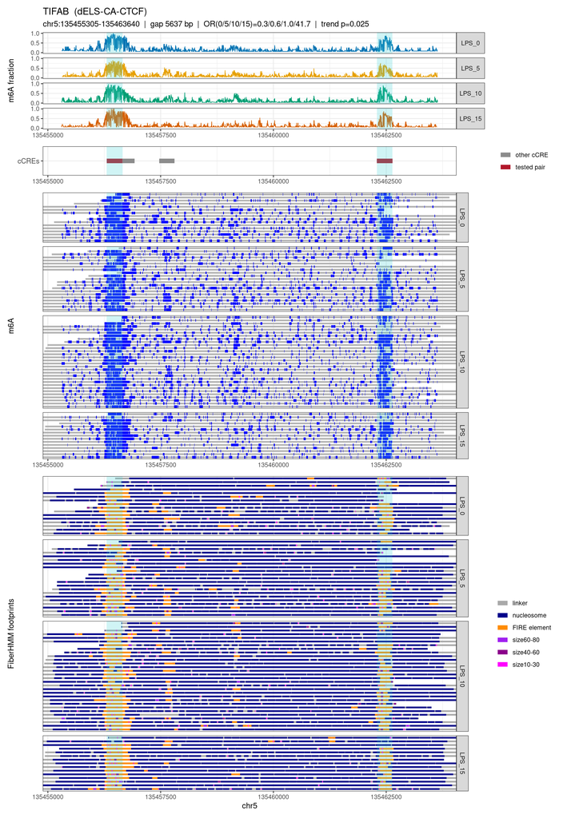

## ZNF837 (pair2_ZNF837_chr19_58376670)

[figure not shown]

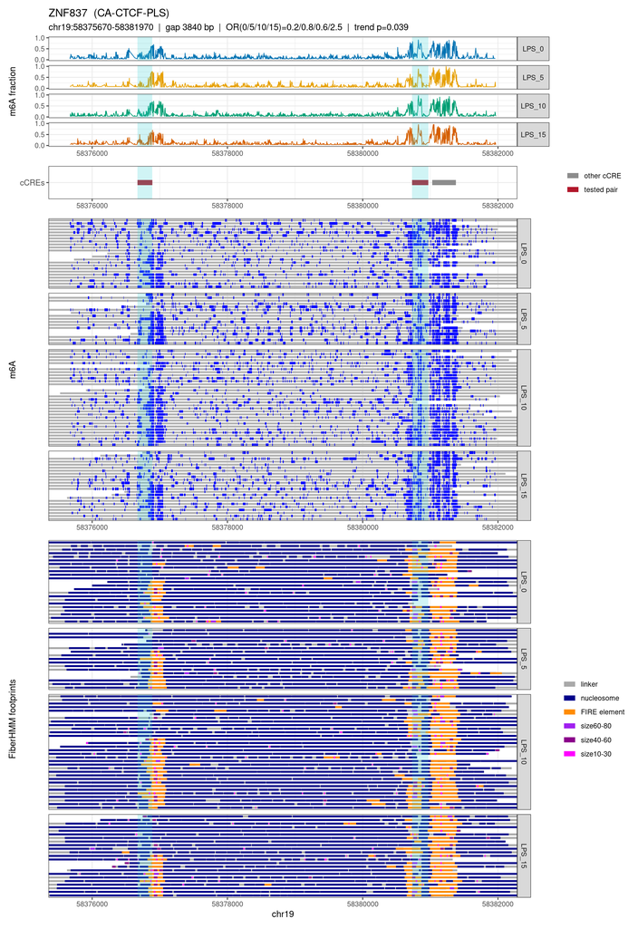

## KLHL32 (pair3_KLHL32_chr6_96917138)

[figure not shown]

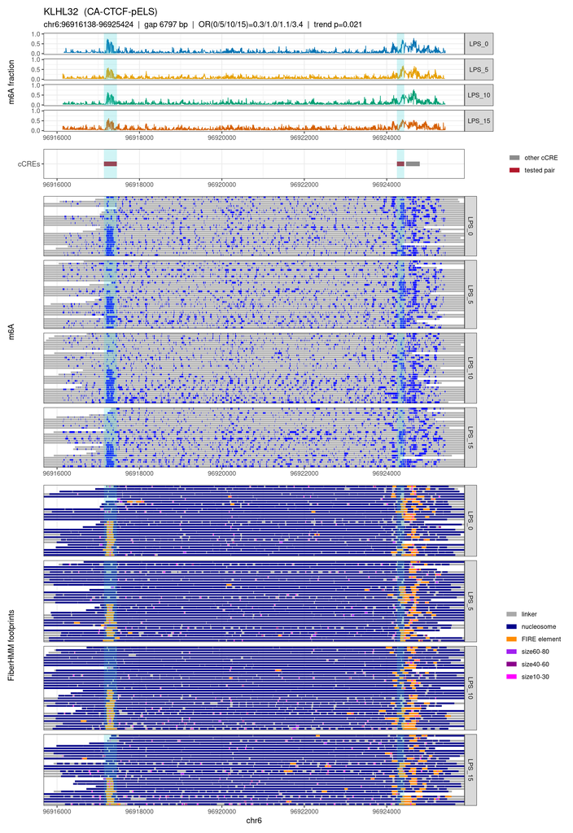

## PDGFRL (pair4_PDGFRL_chr8_17577522)

[figure not shown]

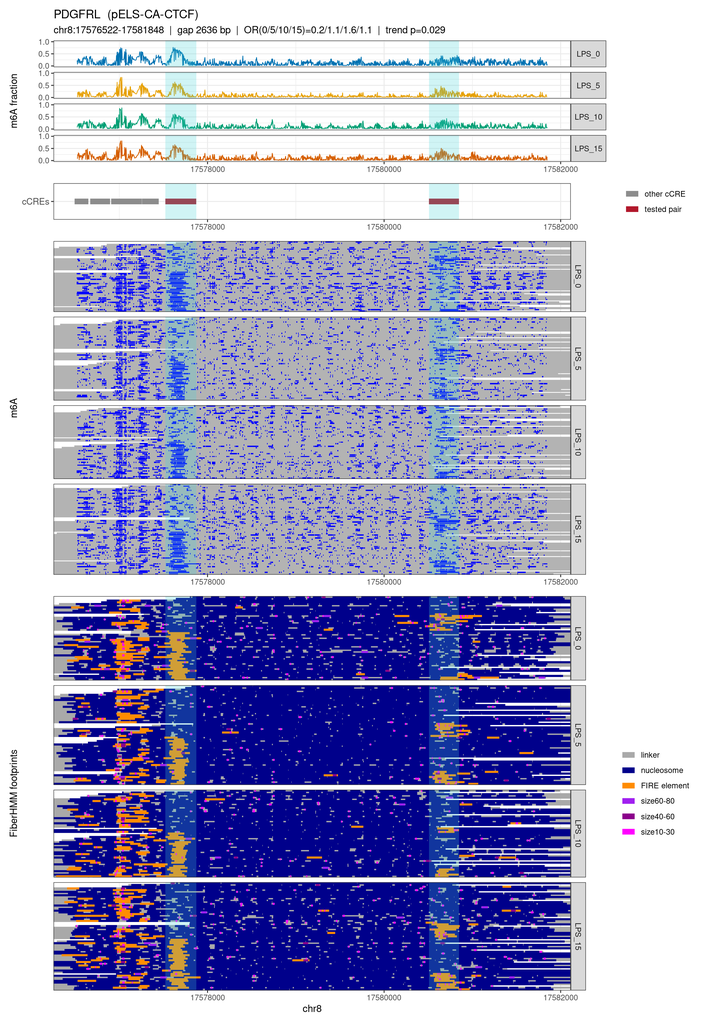

## KCNJ5 (pair5_KCNJ5_chr11_128884782)

[figure not shown]

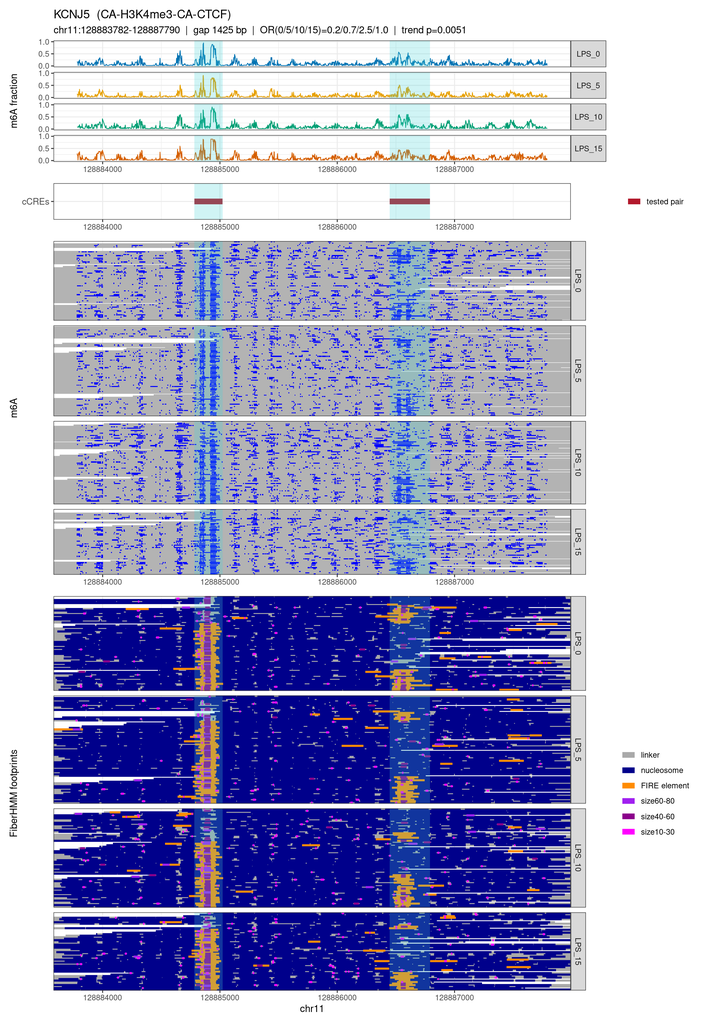

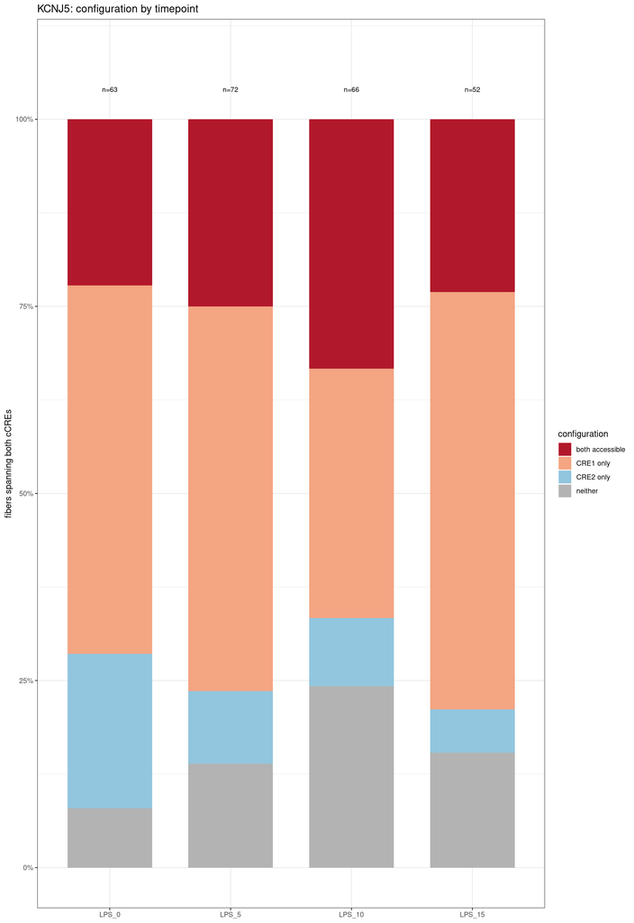

# Configuration counts

```r
if (length(out) > 0 && !all(vapply(out, is.null, logical(1)))) {
  qc <- rbindlist(lapply(names(out), function(nm) {
    if (is.null(out[[nm]])) return(NULL)
    d <- out[[nm]]$labels[!is.na(config)]
    d[, .(n = .N), by = .(sample_name, config)][, pair_id := nm]
  }))
  dcast(qc, pair_id + sample_name ~ config, value.var = "n", fill = 0) |>
    knitr::kable()
} else {
  cat("No figures produced.\n")
}
```

| pair_id | sample_name | both accessible | CRE1 only | CRE2 only | neither |
| --- | --- | --- | --- | --- | --- |
| pair1_TIFAB_chr5_135456305 | LPS_0 | 9 | 4 | 3 | 0 |
| pair1_TIFAB_chr5_135456305 | LPS_10 | 24 | 3 | 3 | 0 |
| pair1_TIFAB_chr5_135456305 | LPS_15 | 12 | 1 | 0 | 2 |
| pair1_TIFAB_chr5_135456305 | LPS_5 | 13 | 7 | 1 | 0 |
| pair2_ZNF837_chr19_58376670 | LPS_0 | 5 | 7 | 9 | 2 |
| pair2_ZNF837_chr19_58376670 | LPS_10 | 9 | 11 | 7 | 5 |
| pair2_ZNF837_chr19_58376670 | LPS_15 | 10 | 2 | 7 | 4 |
| pair2_ZNF837_chr19_58376670 | LPS_5 | 5 | 6 | 3 | 3 |
| pair3_KLHL32_chr6_96917138 | LPS_0 | 5 | 9 | 9 | 5 |
| pair3_KLHL32_chr6_96917138 | LPS_10 | 9 | 7 | 9 | 8 |
| pair3_KLHL32_chr6_96917138 | LPS_15 | 8 | 3 | 7 | 10 |
| pair3_KLHL32_chr6_96917138 | LPS_5 | 6 | 9 | 7 | 10 |
| pair4_PDGFRL_chr8_17577522 | LPS_0 | 4 | 25 | 10 | 10 |
| pair4_PDGFRL_chr8_17577522 | LPS_10 | 5 | 21 | 3 | 22 |
| pair4_PDGFRL_chr8_17577522 | LPS_15 | 10 | 20 | 10 | 23 |
| pair4_PDGFRL_chr8_17577522 | LPS_5 | 8 | 20 | 8 | 22 |
| pair5_KCNJ5_chr11_128884782 | LPS_0 | 14 | 31 | 13 | 5 |
| pair5_KCNJ5_chr11_128884782 | LPS_10 | 22 | 22 | 6 | 16 |
| pair5_KCNJ5_chr11_128884782 | LPS_15 | 12 | 29 | 3 | 8 |
| pair5_KCNJ5_chr11_128884782 | LPS_5 | 18 | 37 | 7 | 10 |